# Practice 1

## Task 1: Proect and create

> Спроектируйте базу данных по требованиям, описанным ниже. Нарисуйте диаграмму спроектированной базы и напишите SQL скрипт, который создаст эту базу данных. Диаграмма должны быть представлена в удобочитаемом формате. При создании скрипта необходимо для всех таблиц определить первичные ключи, и необходимые внешние ключи.

### ER diagram

> Представить реляционную модель базы для хранения информации об административной структуре компании. База содержит следующую информацию: 1. Список отделов и их специализацию (например, бухгалтерия, логистический и т.д.). Отделы имеют иерархическую структуру, т.е. отдел может быть частью какого-то другого отдела (Например, есть два офиса - в Москве и в Петербурге, в каждом офисе есть бухгалтерия и IT отдел; в Москве IT отдел состоит из двух подотделов). 2. Список сотрудников. Для каждого сотрудника необходимо хранить: ФИО, дата рождения, должность, зарплата, отдел в котором он работает, и его непосредственного руководителя. Для одинаковых должностей зарплата одинаковая.

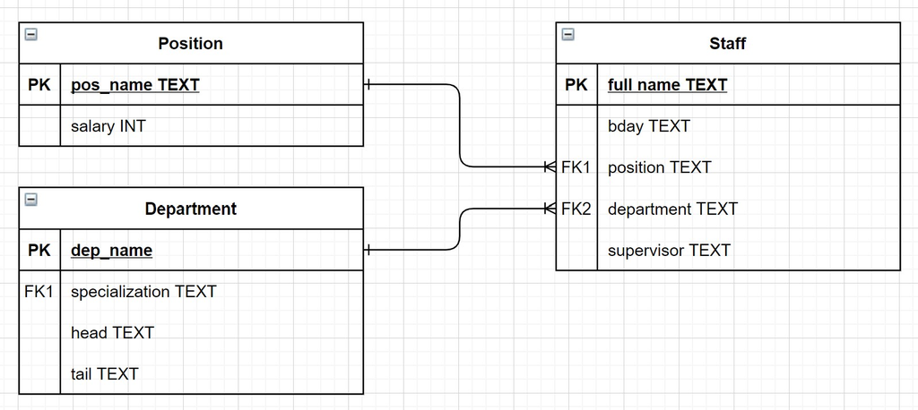

ER

### SQLite code

```
-- Write code

CREATE TABLE IF NOT EXISTS Staff(
    full_name TEXT    PRIMARY KEY    NOT NULL,
    bday     TEXT    NOT NULL,
    position     TEXT    NOT NULL,
    department     TEXT    NOT NULL,
    supervisor  TEXT    NOT NULL,
    FOREIGN KEY (position)
        REFERENCES Position (pos_name),
    FOREIGN KEY (department)
        REFERENCES Department (dep_name),
);

CREATE TABLE IF NOT EXISTS Position(
    pos_name TEXT  PRIMARY KEY   NOT NULL,
    salary INT NOT NULL
);

CREATE TABLE IF NOT EXISTS Department(
    dep_name TEXT  PRIMARY KEY    NOT NULL,
    specialization TEXT NOT NULL,
    head TEXT,
    tail
);
```

## Task 2:

### Subtask 1

> Проанализируйте существующую схему и напишите возможные проблемы, которые могут быть связаны с текущей реализацией.
1. Не понятно зачем нужна таблица Cast для того чтобы следить за фильмами, iswatched looks like logical type.
2. Ограничения на длину имени и названия могут помешать.
3. Если актёры нужны, то про них мало информации
4. Название фильмов не всегда уникально, поэтому как PK it is not legal

поэтому двигаемся к

### Subtask 2

> Во второй версии было решено расширить функционал текущей базы. Предложите свой вариант расширения, такой, чтобы в ней сохранялась вся текущая информация и была возможность сохранять информацию, описанную ниже. Нарисуйте диаграмму новой схемы базы данных.
- Исправте недочеты, которые вы описали в ответе на первый вопрос.
- У некоторых фильмов может быть несколько режиссеров.
- Хотелось бы хранить не только список актеров фильма, но и имена продюсера и сценариста. Возможно, в дальнейшем, будет желание добавить других участников съемочного процесса.
- Т.к. в семье может быть несколько человек, кто отмечает просмотренные фильмы, то хотелось бы сохранять информацию отдельно для каждого члена семьи.

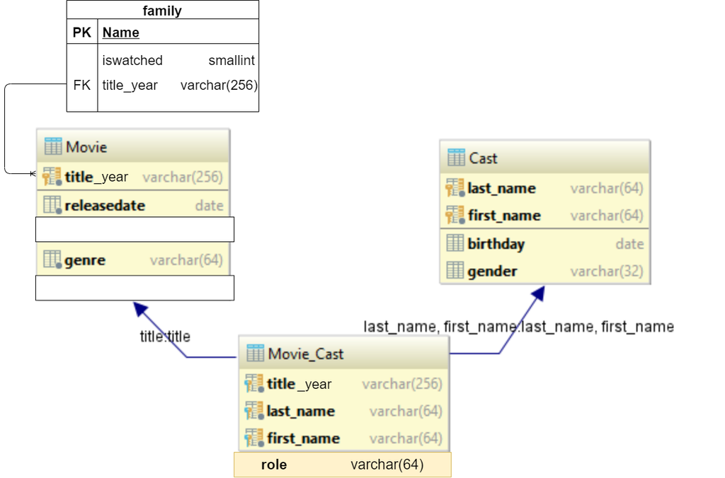

ER2

В состав добавим параметр роли в конкретном фильме, что решит и задачу нескольких режиссёров и если режиссер будет актёром, а продюсеров добавлять одно удовольствие. Непонятно только зачем знать из гендер и дату рождения, но эту проблему решим в версии 3. Хранение не очень эффективное, но так как это только для дома мы можем не оптимизировать базу.

Функция разных членов семьи добавлена через таблицу family, где на каждого члена семьи заводится пара фильм - просмотрено?